# Final Project: Exploratory Data Analysis

**Question 1:** What periods were different popular distributors the most prolific?

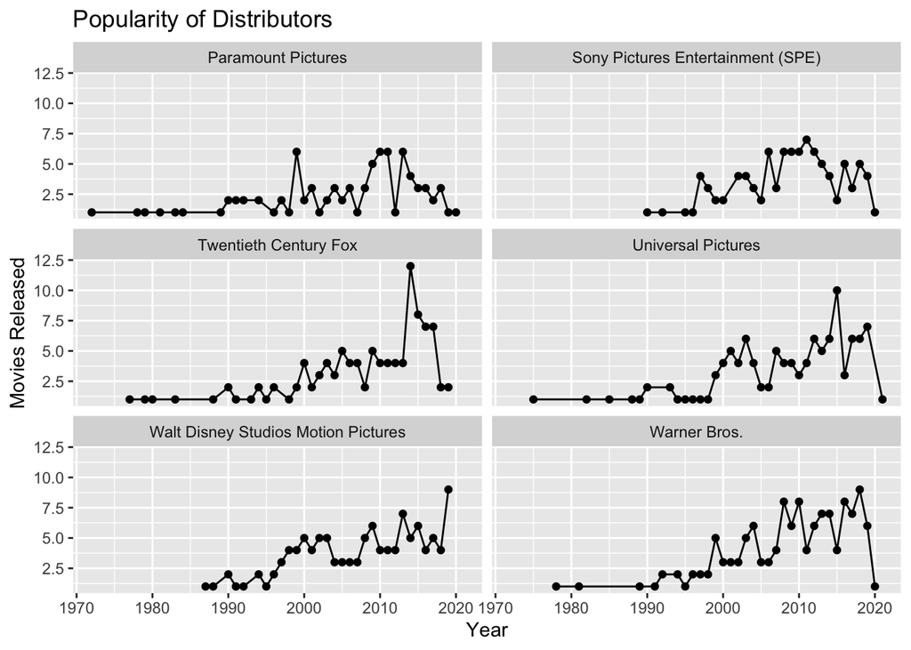

**Question 1 Follow-up:** Is there an indication of covariance between the most popular distributors? How do the most popular distributors’ movie releases line up with each other?

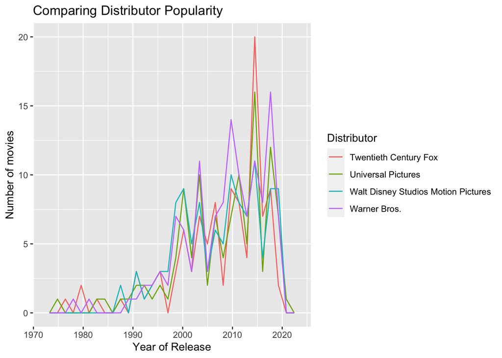

**Question 2:** What is the relationship between the distributors and the percent of sales?

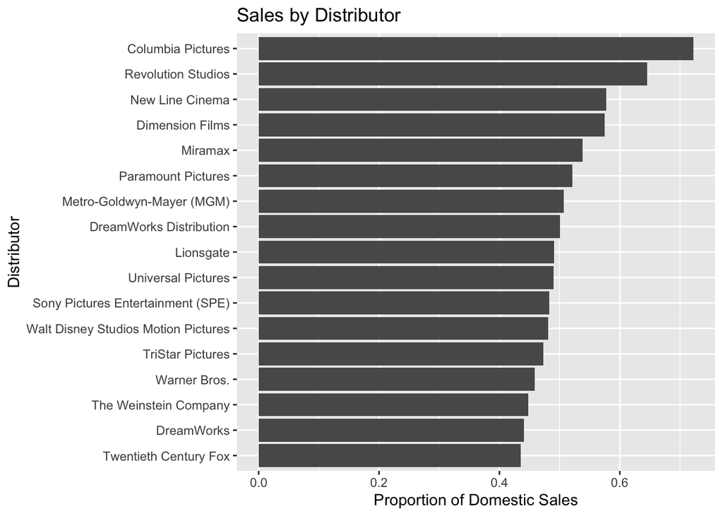

**Question 3:** Of the overall most popular genres, how have trends in which genre is most popular shifted over the years?

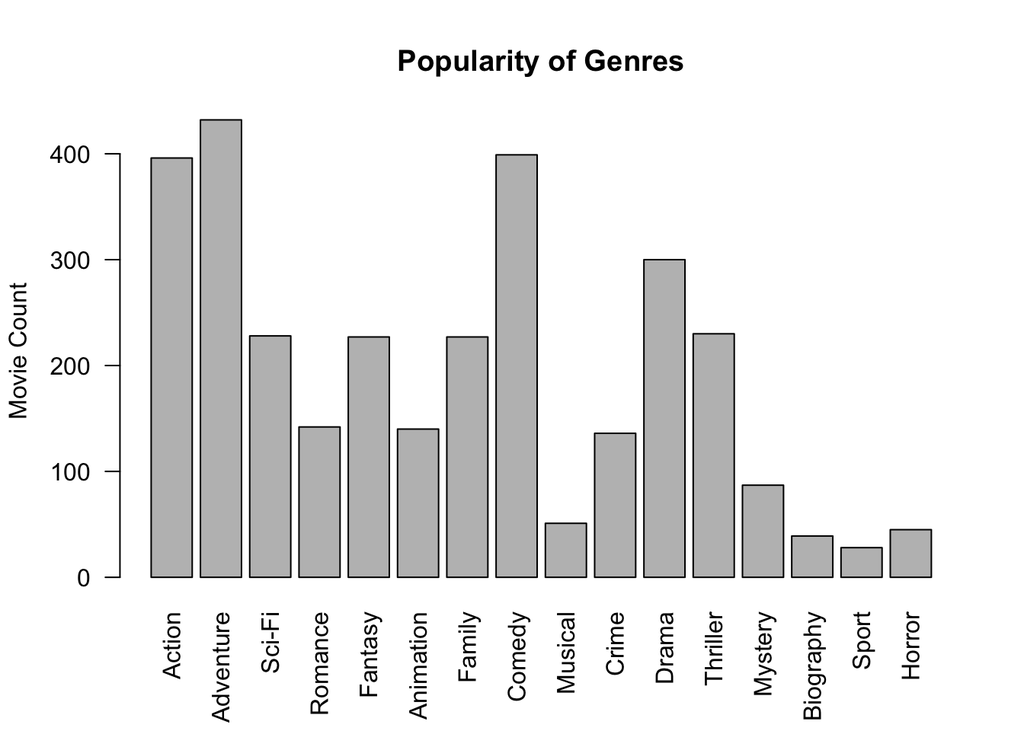

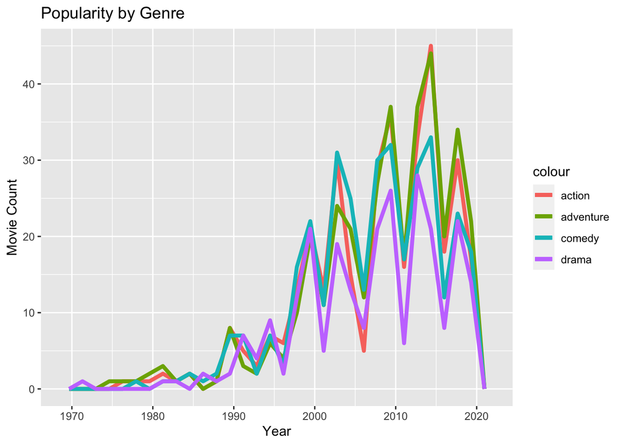

**Question 4:** How do international and domestic sales respond to different runtime?

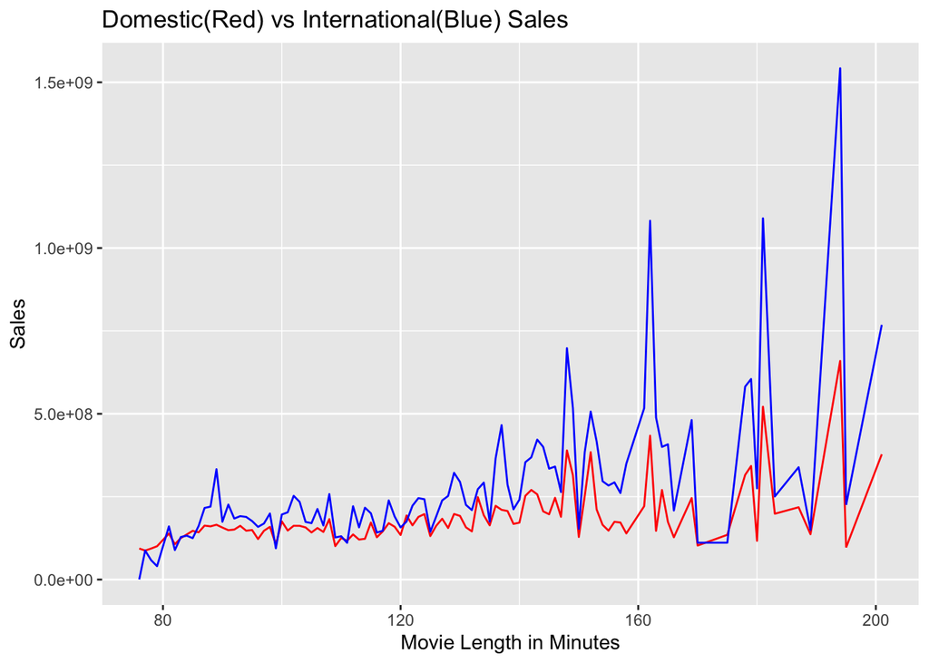

**Question 5:** Is there a difference in the international and domestic preference of genres?

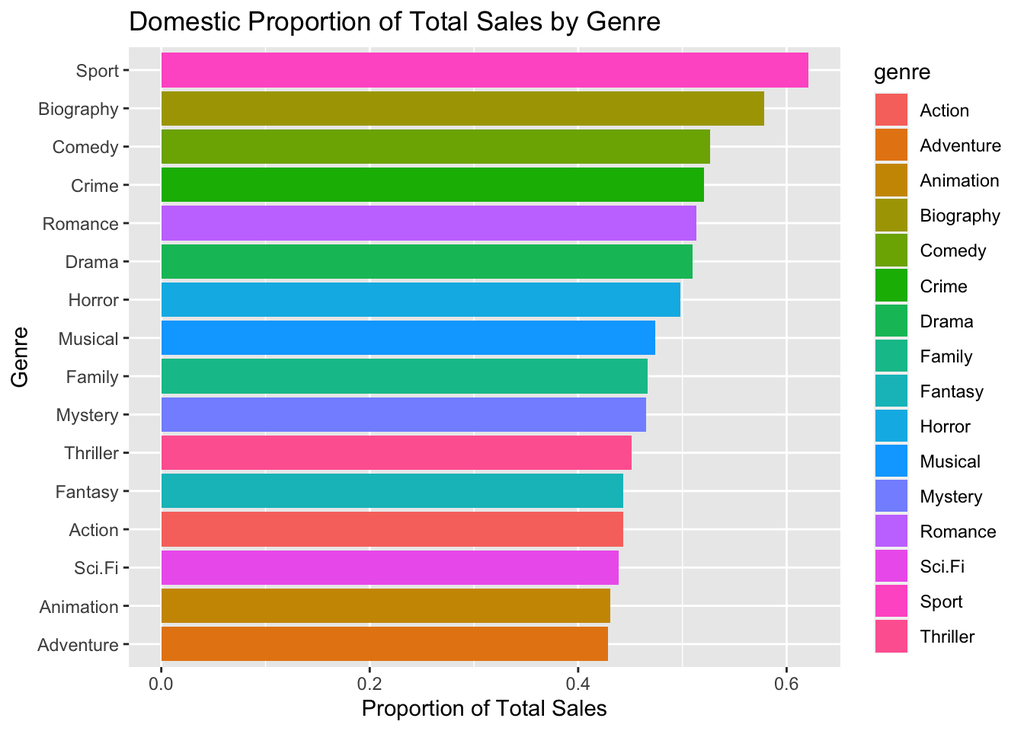

**Question 6:** How does run time affect the popularity of movie?

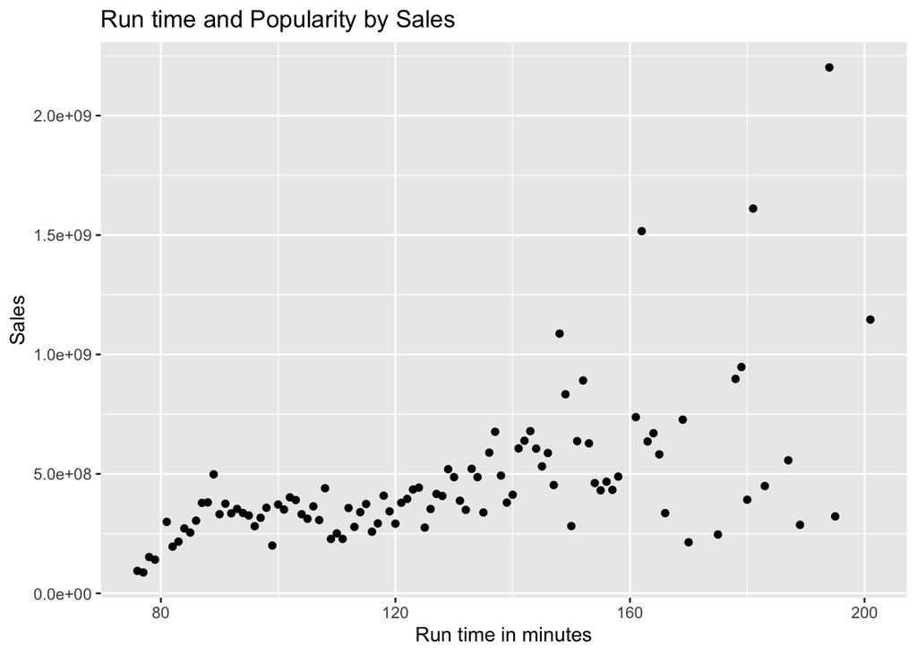

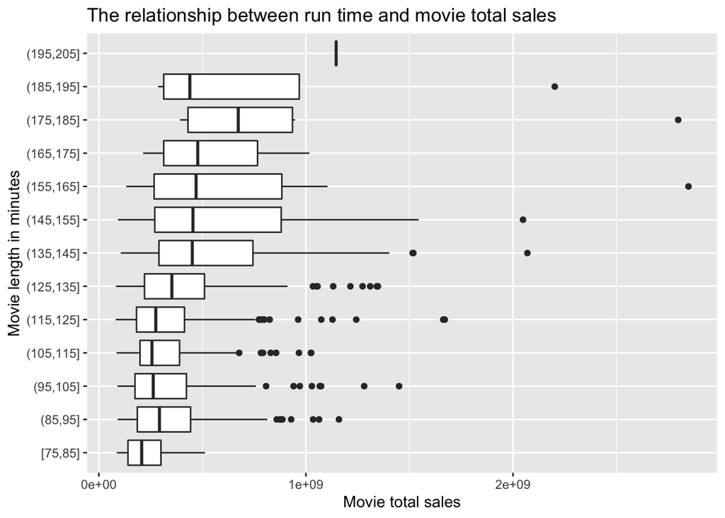

**Question 7:** What percentage do domestic sales contain of the total world sales?

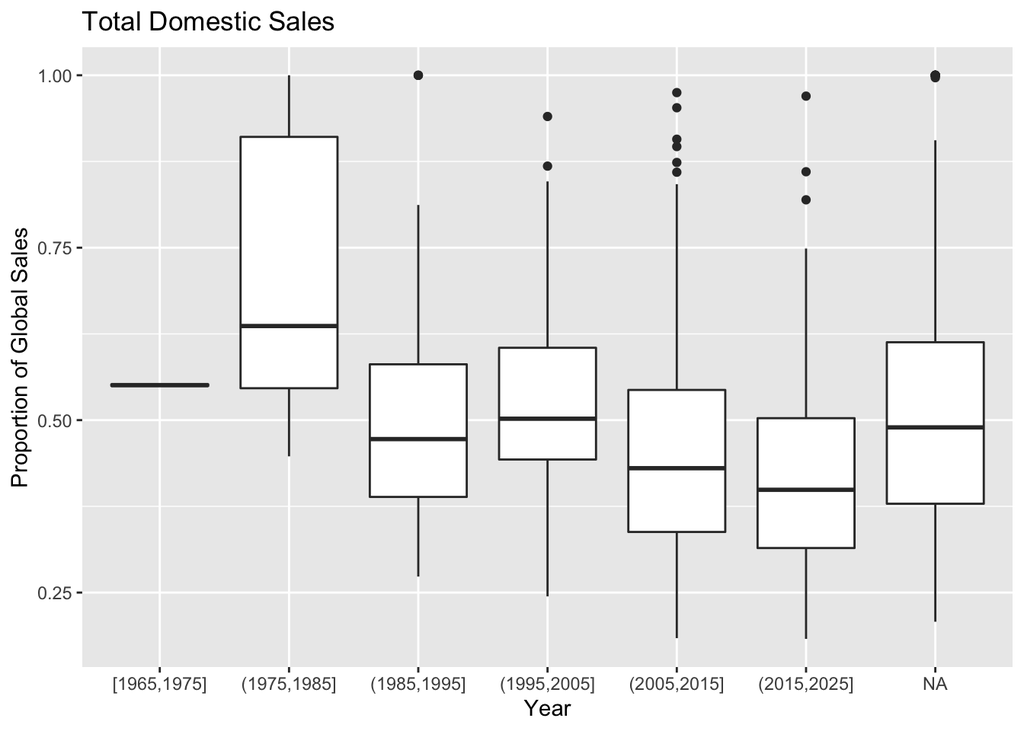

**Question 7 Follow-up:** How does genre popularity differ between international and domestic audiences? Does a similar trend follow for popular genres such as Action and Adventure?

[figure not shown]

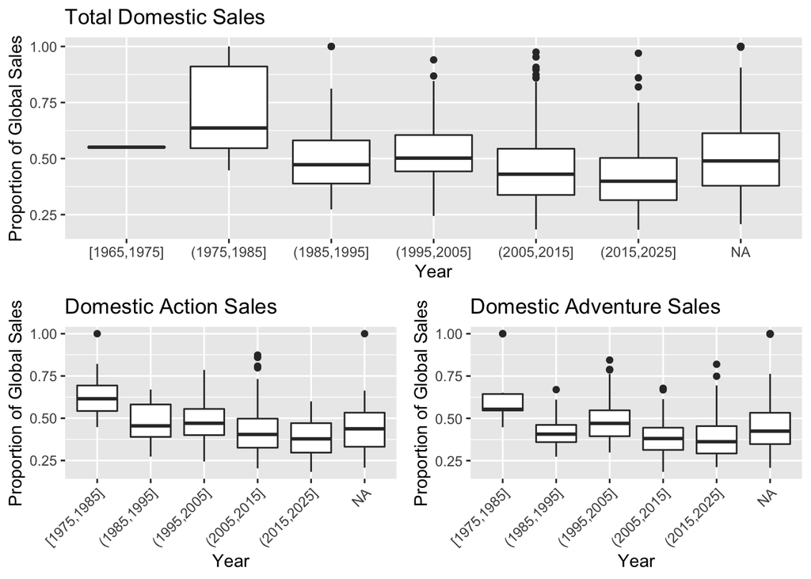

**Question 8:** Is there a correlation between movie name length and sales?

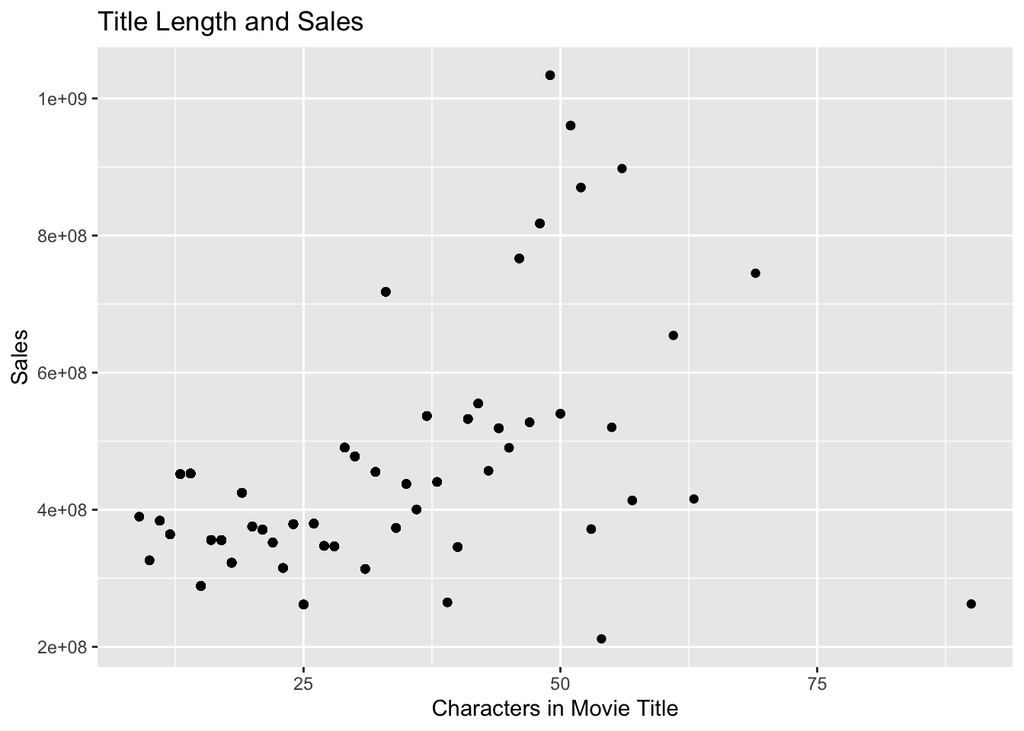

**Question 9:** How does grouping/trends within the most popular distributors work?

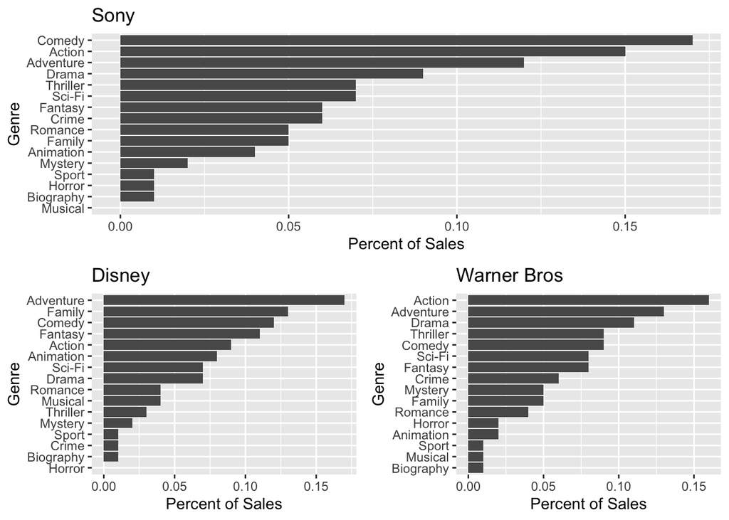

**Question 10:** Do release dates have a seasonal affect on sales?

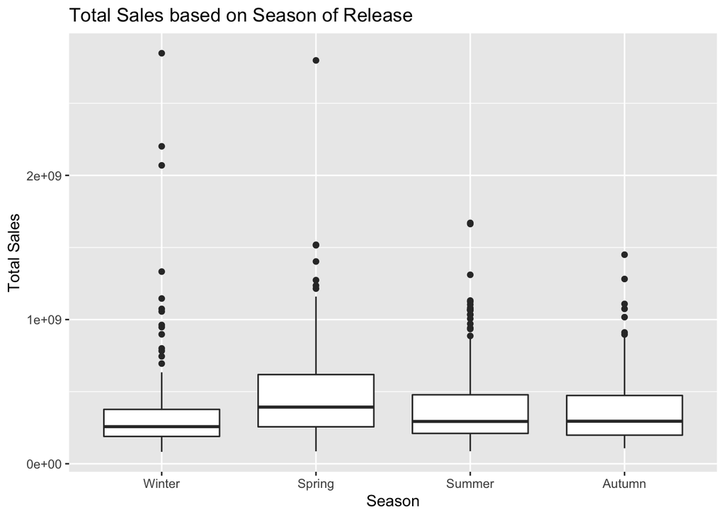

**Question 11:** Does the release year impact the run time? Is there an increase/decrease?

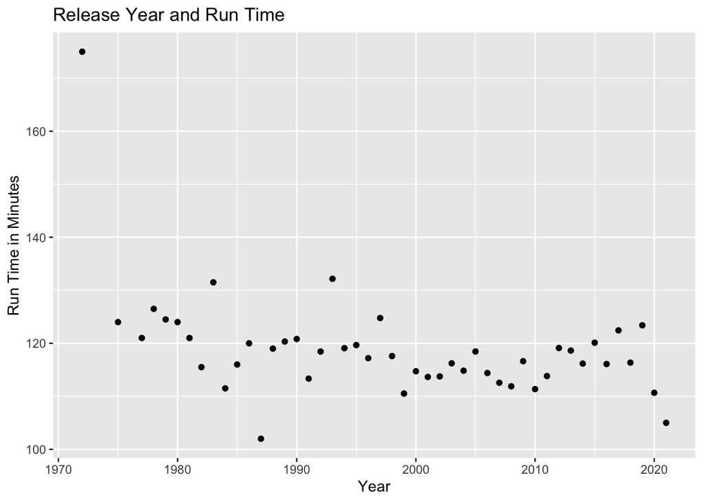

**Question 12:** Do genres tend to stick to a certain range of run-time?

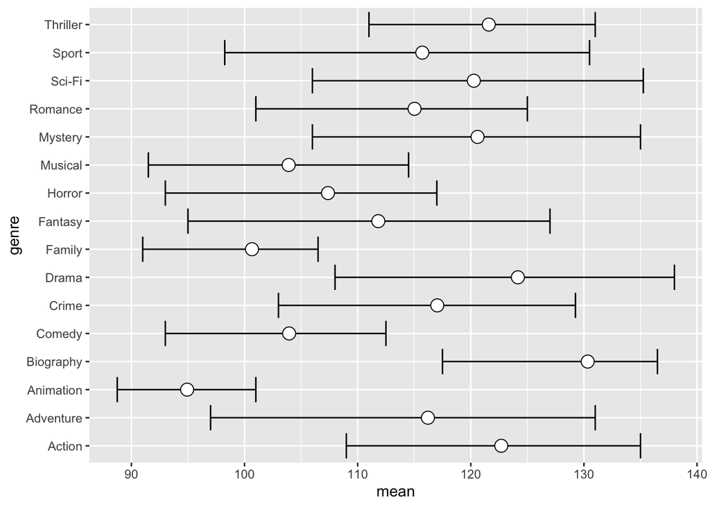

**Reflection Paragraphs:** In our initial questions, there were two types of questions we were exploring: relationships between different groups in a variable and where we wanted to see if a relationship existed at all. Questions that fell in the first category included comparing the popularity of different distributors over time, how international and domestic sales were split, and audience preference of genres. These questions allowed us to see differences within a variable (distributors, genre) and compare the responses of these subgroups to each other. Interestingly enough, the second category of our questions revealed that moderate to strong relationships existed between more variables than originally thought. This included positive correlations between the characters in a movie name and run-time with the number of sales, which we did not expect.